# ML_Finance

### Introduction

We are using package *quantmod* , and function *getSymbol()* to download the data from the **yahoo** or **google finance**. So, we need to need all the Symbols of each stock, since different stocks have a unique abbrevation.

```r
# install.packages('quantmod')
## uncommond above to install quantomod
library(quantmod)
```

### Loading data

First, we need to load the symbols list:

```r
NASDAQ <- read.delim("C:/Users/QIZHAOR/Desktop/PROGRAM/R/ML_Fin/NASDAQ.txt", header=FALSE)
symbols <-as.vector(factor(NASDAQ$V1))
```

Then, we need to define some function for computing the daily ruturn of the stock.

```r
daFa <- data.frame()
get.linRtn <- function(trick,From){
  symbol <- getSymbols(trick, from = From,
                       auto.assign = F,warnings = F)

  data <- as.data.frame(periodReturn(symbol, period = 'daily'))
  colnames(data) <- as.character(paste(trick,"Linrtn"))
  assign(trick,data, .GlobalEnv)
}
```

```r
set.seed(400)
```

we are about to draw 30 symbols from the list at random.

```r
assets <- sample(symbols,30)
```

From now no, we are woring on these 30 stocks behaviors, and try to distinguish their behavior over a period of time.

We need to specify the time range:

```r
From <- '2019-01-01'
#To <- '2019-01-01'
```

We are using for-loop and the function defined aboved to generate the data we want:

```r
for (asset in assets){
  get.linRtn(asset,From)
}
```

```r
my_function <- function(t){
  as.vector(data.frame(eval(parse(text = t))))
}

daFa <- as.data.frame(lapply(assets, my_function))
str(daFa)
```

```
'data.frame':   198 obs. of  30 variables:
 $ KNSA.Linrtn : num  -0.03414 -0.00113 -0.02297 0.00154 -0.01154 ...
 $ THOR.Linrtn : num  0.05816 -0.07459 -0.04364 -0.0602 -0.00944 ...
 $ LTXB.Linrtn : num  0.04684 0.00302 0.03888 -0.00232 0.00931 ...
 $ AMPH.Linrtn : num  0.0056 -0.01518 0.06012 0.00533 0.00771 ...
 $ ISDX.Linrtn : num  0 0 0.0225 0 0 ...
 $ SFST.Linrtn : num  0.010582 0.000924 0.029846 0.010158 0.011535 ...
 $ LCNB.Linrtn : num  0.01974 -0.01613 0.02033 0.00193 -0.00257 ...
 $ HELE.Linrtn : num  0.000691 -0.015043 0.043793 -0.007242 -0.12829 ...
 $ EPSN.Linrtn : num  -0.00226 0.00227 0 0 0 ...
 $ INNT.Linrtn : num  0.03084 0.02137 0.05858 -0.00791 -0.03586 ...
 $ TCX.Linrtn  : num  0.01897 -0.02702 0.03268 0.02099 0.00209 ...
 $ RMNI.Linrtn : num  0.0758 -0.0594 0.0966 0.0036 0.0215 ...
 $ OXLC.Linrtn : num  0.03774 -0.00909 0.01223 0.01208 -0.00299 ...
 $ RNET.Linrtn : num  0.0928 -0.0168 0.0447 0.0214 0.0105 ...
```

[output cut: 16 more lines]

### Clustering

There are three packages are using:

```r
# install.packages(c("tidyverse","cluster","factoextra")) ## uncommond to installs
library(tidyverse) # data manipulation
library(cluster) # clustering algorithms
library(factoextra) # clustering algorithms & visualization
```

_note: first that we need to transform the data.frame so that row contain the stocks, the columns contain the features. Here, the feature we are going to investigate is each stock’s daily return.

```r
daFa <- t(daFa)
daFa
```

[output not shown]

[output cut: 96 more lines]

[output not shown]

```r
k2 <- kmeans(daFa,centers = 3 , nstart = 15)
str(k2)
```

```
List of 9
 $ cluster     : Named int [1:30] 1 1 1 1 1 1 1 1 1 1 ...
  ..- attr(*, "names")= chr [1:30] "KNSA.Linrtn" "THOR.Linrtn" "LTXB.Linrtn" "AMPH.Linrtn" ...
 $ centers     : num [1:3, 1:198] 0.0208 0.1656 0 -0.0128 -0.1421 ...
  ..- attr(*, "dimnames")=List of 2
  .. ..$ : chr [1:3] "1" "2" "3"
  .. ..$ : chr [1:198] "2019-01-02" "2019-01-03" "2019-01-04" "2019-01-07" ...
 $ totss       : num 16.4
 $ withinss    : num [1:3] 3.99 0 0
 $ tot.withinss: num 3.99
 $ betweenss   : num 12.4
 $ size        : int [1:3] 28 1 1
 $ iter        : int 3
 $ ifault      : int 0
 - attr(*, "class")= chr "kmeans"
```

vizionlized :

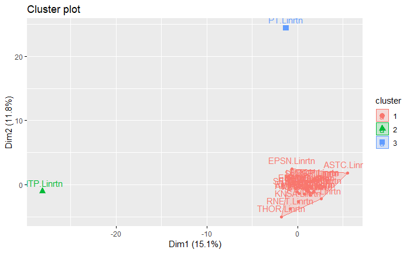

```r
fviz_cluster(k2,data = daFa)
```

```r
k2$cluster
```

```
 KNSA.Linrtn  THOR.Linrtn  LTXB.Linrtn  AMPH.Linrtn  ISDX.Linrtn  SFST.Linrtn  LCNB.Linrtn  HELE.Linrtn  EPSN.Linrtn
           1            1            1            1            1            1            1            1            1
 INNT.Linrtn   TCX.Linrtn  RMNI.Linrtn  OXLC.Linrtn  RNET.Linrtn  NBIX.Linrtn    PT.Linrtn  SMSI.Linrtn  EBAY.Linrtn
           1            1            1            1            1            1            3            1            1
 MGIC.Linrtn SLMBP.Linrtn  MMSI.Linrtn  ICHR.Linrtn  ASTC.Linrtn  BOOM.Linrtn  CHKP.Linrtn  IPGP.Linrtn  TTEK.Linrtn
           1            1            1            1            1            1            1            1            1
LMRKP.Linrtn  PLUS.Linrtn   MTP.Linrtn
           1            1            2
```